# Analysing Flights

Authors

Lenny Budlinger

Thomas van der Wardt

Oliver Zingg

## 0.1 Packages & Load

```r
# Scientific notation
options(scipen=999)

# Load packages -----------------------------

library(tidyverse) # ggplot for plotting, dplyr for data manipulation
library(lubridate) # package for handling time variable
library(hms) # handling time
library(gt) # Print tables
library(DT)
library(forcats) # Reorder factor levels
library(kableExtra)
library(janitor)
library(multcomp) # Multiple comparison tests
library(patchwork) #plots side by side
library(kernlab) # SVM methodology
library(e1071) # SVM methodology
library(ISLR) # contains example data set "Khan"
library(RColorBrewer)
library(caret)
library(doParallel)
library(randomForest) #For feature selection
library(caret)
library(keras)
library(ROSE)
library(pROC)
library(DMwR2)
library(mgcv)
library(smotefamily)
library(tensorflow)
library(car)
library(keras)
library(neuralnet)

load("./../Data/LGA_preprocessed.rda")
```

## 0.2 Description of the LGA Data set

### 0.2.1 Total Flights and Delays

For the following table we defined a flight as delayed if the arrival or departure delay is greater than 30 minutes.

```r
# Create table
planes %>%
  mutate(index_late_arr = ifelse(ARR_DELAY > 30, 1, 0),
         index_late_dep = ifelse(DEP_DELAY > 30, 1, 0)) %>%
  group_by(OP_CARRIER) %>%
  summarise(
    Total_flights = n(),
    Total_delayed_arr = sum(index_late_arr == 1, na.rm = TRUE),
    percentage_delayed_arr = Total_delayed_arr / Total_flights * 100,

    Total_delayed_dep = sum(index_late_dep == 1, na.rm = TRUE),
    percentage_delayed_dep = Total_delayed_dep / Total_flights * 100,

    median_dep_delay = median(DEP_DELAY, na.rm = TRUE),
    median_arr_delay = median(ARR_DELAY, na.rm = TRUE),
    median_distance = median(DISTANCE, na.rm = TRUE)
  ) %>%
  ungroup() %>%
  mutate(
    percentage_of_total = Total_flights / sum(Total_flights) * 100
  ) %>%
  mutate(across(where(is.double), ~round(.x, 2))) %>%
  relocate(percentage_of_total, .after = Total_flights)  %>%
  arrange(desc(Total_flights)) %>%
  gt() %>%
  tab_options(
    table.font.size = px(8),
  )
```

| OP_CARRIER | Total_flights | percentage_of_total | Total_delayed_arr | percentage_delayed_arr | Total_delayed_dep | percentage_delayed_dep | median_dep_delay | median_arr_delay | median_distance |
| --- | --- | --- | --- | --- | --- | --- | --- | --- | --- |
| AA | 16968 | 16.91 | 2086 | 12.29 | 1769 | 10.43 | -3 | -8 | 1097 |
| DL | 14455 | 14.41 | 1618 | 11.19 | 1359 | 9.40 | -2 | -7 | 761 |
| US | 12774 | 12.73 | 889 | 6.96 | 580 | 4.54 | -6 | -10 | 214 |
| MQ | 11298 | 11.26 | 1368 | 12.11 | 1243 | 11.00 | -4 | -7 | 431 |
| OH | 11162 | 11.12 | 2018 | 18.08 | 1796 | 16.09 | 0 | 0 | 641 |
| NW | 8754 | 8.72 | 1219 | 13.93 | 1025 | 11.71 | -2 | -4 | 1011 |
| UA | 6578 | 6.56 | 840 | 12.77 | 858 | 13.04 | -3 | -11 | 733 |
| FL | 5954 | 5.93 | 1001 | 16.81 | 923 | 15.50 | -4 | -5 | 761 |
| CO | 3666 | 3.65 | 510 | 13.91 | 436 | 11.89 | -2 | -5 | 1416 |
| B6 | 2899 | 2.89 | 530 | 18.28 | 474 | 16.35 | -2 | -3 | 1076 |
| 9E | 1547 | 1.54 | 173 | 11.18 | 160 | 10.34 | -3 | -9 | 659 |
| WN | 1422 | 1.42 | 206 | 14.49 | 244 | 17.16 | 1 | -11 | 725 |
| YV | 1041 | 1.04 | 149 | 14.31 | 155 | 14.89 | -3 | -9 | 229 |
| XE | 890 | 0.89 | 135 | 15.17 | 131 | 14.72 | -6 | -11 | 418 |
| F9 | 727 | 0.72 | 110 | 15.13 | 70 | 9.63 | -3 | 0 | 1619 |
| EV | 172 | 0.17 | 21 | 12.21 | 24 | 13.95 | -2 | -9 | 617 |
| OO | 27 | 0.03 | 7 | 25.93 | 4 | 14.81 | -1 | 4 | 478 |

### 0.2.2 Departure Time

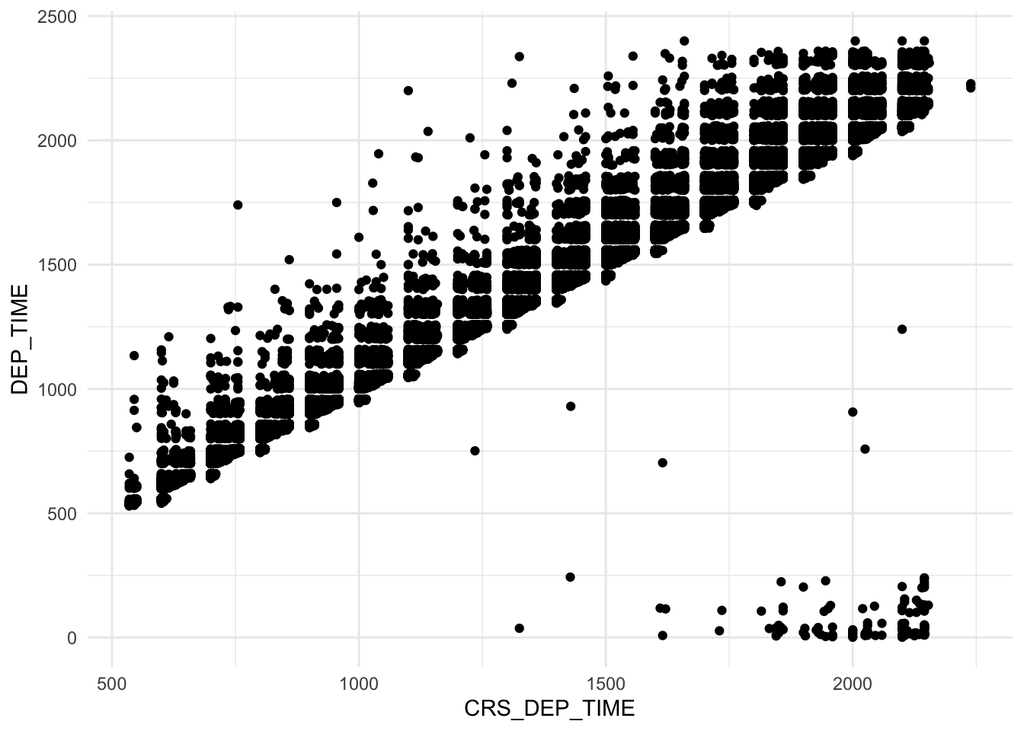

```r
planes %>%
  ggplot(aes(x = CRS_DEP_TIME, y = DEP_TIME)) +
  geom_point() +
  theme_minimal()
```

This plot shows the planned departure time on the x axis and the actual departure time an the y axis. Points on the diagonal departed on time. On the bottom right of the plot we see a few cases of flights that have a delay and depart on the next day early morning. This should be considered when using `DEP_TIME` in a statistical model. Since flights before 5 am are systematic different from flights after 5 am since these flights were planned to depart the day before.

### 0.2.3 Arrival Delay by Day and Season

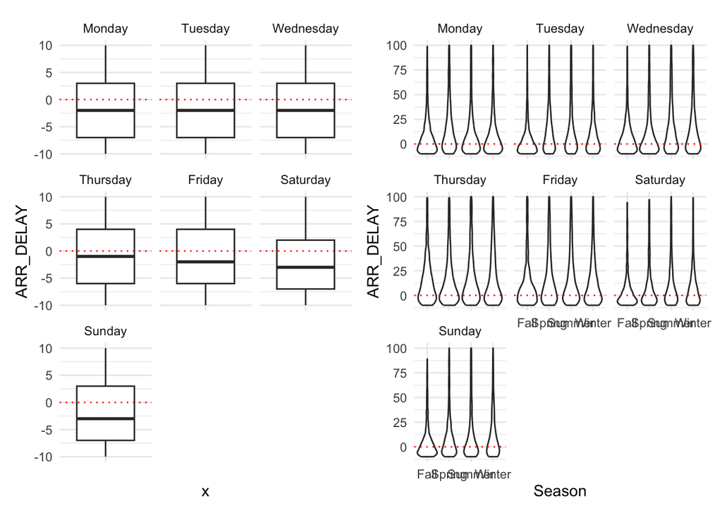

```r
p1 <- planes %>%
  mutate(Weekday = fct_relevel(Weekday, "Monday", "Tuesday", "Wednesday", "Thursday", "Friday", "Saturday", "Sunday")) %>%
  ggplot(aes(x = "", y = ARR_DELAY)) +
  geom_boxplot(outlier.colour = "red",outlier.shape = 1) +
  geom_hline(yintercept  = 0, color = "red",linetype='dotted') +
  facet_wrap(~ Weekday)+
  scale_y_continuous(limits = c(-10,10)) +
  theme_minimal()

p2 <- planes %>%
  mutate(Weekday = fct_relevel(Weekday, "Monday", "Tuesday", "Wednesday", "Thursday", "Friday", "Saturday", "Sunday")) %>%
  ggplot(aes(Season, ARR_DELAY)) +
  geom_violin() +
  geom_hline(yintercept  = 0, linetype='dotted',color = "red") +
  facet_wrap(~Weekday) +
  scale_y_continuous(limits = c(-10,100)) +
  theme_minimal()

p1 + p2 + plot_layout(ncol = 2)
```

Arrival Delay are similar across the weekdays and season. On weekends the median of arrival delay seems to be a bit lower. The violin plot give us a feeling of how skewed arrival delay is and how different the median and average are. Other variables in this data set are similarly skewed, therefore modeling the average may not represent the biggest part of the data. We will later see if we can handle this skewness.

```r
planes %>%
  dplyr::select(DEP_DELAY,ARR_DELAY,CRS_DEP_TIME,WHEELS_OFF,WHEELS_ON, DISTANCE,ACTUAL_ELAPSED_TIME, TAXI_OUT, TAXI_IN ) %>%
  cor(use = "complete.obs") %>% kable(caption = "Correlation matrix of different variables")
```

Correlation matrix of different variables

|  | DEP_DELAY | ARR_DELAY | CRS_DEP_TIME | WHEELS_OFF | WHEELS_ON | DISTANCE | ACTUAL_ELAPSED_TIME | TAXI_OUT | TAXI_IN |
| --- | --- | --- | --- | --- | --- | --- | --- | --- | --- |
| DEP_DELAY | 1.0000000 | 0.8879422 | 0.1780300 | 0.2329716 | 0.0879676 | 0.0530508 | 0.0608624 | 0.0540390 | -0.0049062 |
| ARR_DELAY | 0.8879422 | 1.0000000 | 0.1449869 | 0.2149834 | 0.0900263 | 0.0343948 | 0.1903733 | 0.4001428 | 0.0866103 |
| CRS_DEP_TIME | 0.1780300 | 0.1449869 | 1.0000000 | 0.9710676 | 0.8135008 | -0.0707239 | -0.0456351 | 0.1120957 | -0.0622022 |
| WHEELS_OFF | 0.2329716 | 0.2149834 | 0.9710676 | 1.0000000 | 0.8279598 | -0.0603341 | -0.0160242 | 0.1730932 | -0.0561931 |
| WHEELS_ON | 0.0879676 | 0.0900263 | 0.8135008 | 0.8279598 | 1.0000000 | 0.0066490 | 0.0596126 | 0.1755272 | -0.0181294 |
| DISTANCE | 0.0530508 | 0.0343948 | -0.0707239 | -0.0603341 | 0.0066490 | 1.0000000 | 0.9298512 | -0.0095594 | 0.1186520 |
| ACTUAL_ELAPSED_TIME | 0.0608624 | 0.1903733 | -0.0456351 | -0.0160242 | 0.0596126 | 0.9298512 | 1.0000000 | 0.2885034 | 0.2081655 |
| TAXI_OUT | 0.0540390 | 0.4001428 | 0.1120957 | 0.1730932 | 0.1755272 | -0.0095594 | 0.2885034 | 1.0000000 | -0.0091804 |
| TAXI_IN | -0.0049062 | 0.0866103 | -0.0622022 | -0.0561931 | -0.0181294 | 0.1186520 | 0.2081655 | -0.0091804 | 1.0000000 |

This correlation plot helps us understand the relationship and colinearity among the potential variables used in our models. Some variables are time based (for example: `CRS_DEP_TIM`, `WHEELS_OFF`) with small differences, making them nearly perfect correlated. Such variables shouldn’t be included in the model together as they make the coefficients unstable. Other than that interesting potential predictors can be assessed from this correlation matrix.

# 1 Linear Model

**Aim: Investigating the factors contributing to delays in arrival.**

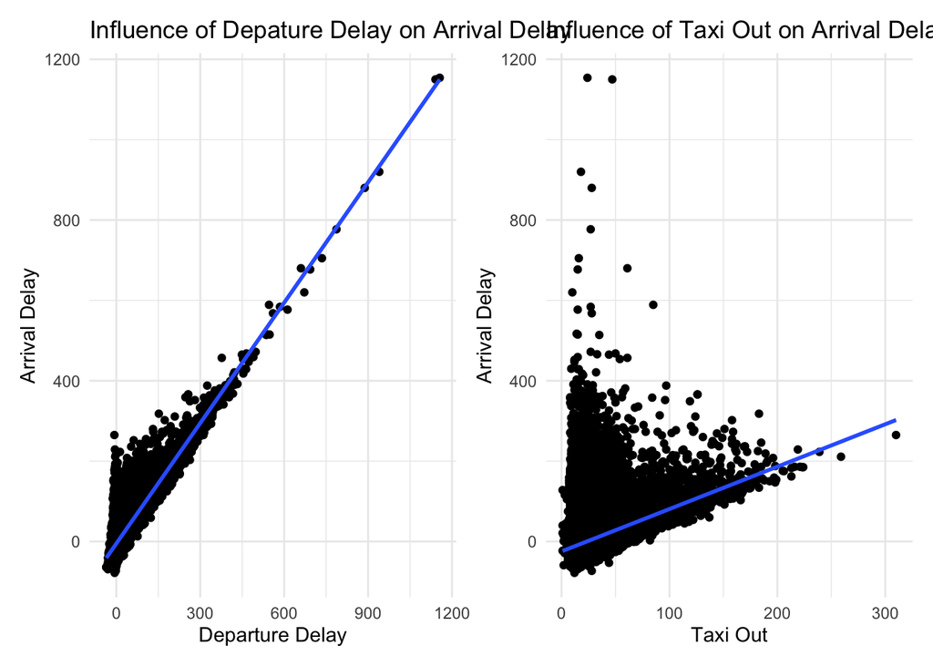

```r
p1 <- planes %>%
  ggplot(aes(x = DEP_DELAY, y = ARR_DELAY)) +
  geom_point() +
  geom_smooth(method = "lm") +
  theme_minimal() +
  labs(title="Influence of Depature Delay on Arrival Delay",
       x = "Departure Delay",
       y = "Arrival Delay")

p2 <- planes %>%
  ggplot(aes(x = TAXI_OUT, y = ARR_DELAY)) +
  geom_point() +
  geom_smooth(method = "lm") +
  theme_minimal() +
  labs(title = "Influence of Taxi Out on Arrival Delay",
       x = "Taxi Out",
       y = "Arrival Delay")

p1 + p2 + plot_layout(ncol = 2)
```

```
Analysis of Variance Table

Model 1: ARR_DELAY ~ DEP_DELAY
Model 2: ARR_DELAY ~ DEP_DELAY + TAXI_OUT
  Res.Df      RSS Df Sum of Sq      F                Pr(>F)
1  96067 34554235
2  96066 14239138  1  20315097 137058 < 0.00000000000000022 ***
---
Signif. codes:  0 '***' 0.001 '**' 0.01 '*' 0.05 '.' 0.1 ' ' 1
```

```
Single term deletions

Model:
ARR_DELAY ~ DEP_DELAY + TAXI_OUT + OP_CARRIER
           Df Sum of Sq       RSS    AIC   F value                Pr(>F)
<none>                   13177731 472814
DEP_DELAY   1 122296267 135473998 696677 891394.49 < 0.00000000000000022 ***
TAXI_OUT    1  20788072  33965803 563773 151520.35 < 0.00000000000000022 ***
OP_CARRIER 16   1061408  14239138 480224    483.52 < 0.00000000000000022 ***
---
Signif. codes:  0 '***' 0.001 '**' 0.01 '*' 0.05 '.' 0.1 ' ' 1
```

We use `drop1` function, since `OP_CARRIER` has more than two levels. The addition of the `OP_CARRIER` variable significantly improves the model fit.

**Show ChatGPT classification**

```r
planes <- planes %>%
  dplyr::mutate(OP_CARRIER_Tier = dplyr::recode(OP_CARRIER,
    # Expensive
    "AA" = "Expensive",
    "DL" = "Expensive",
    "UA" = "Expensive",
    "CO" = "Expensive",

    # Cheap
    "B6" = "Cheap",
    "F9" = "Cheap",
    "FL" = "Cheap",
    "WN" = "Cheap",

    # Mid-tier
    "9E" = "Mid-tier",
    "EV" = "Mid-tier",
    "MQ" = "Mid-tier",
    "OH" = "Mid-tier",
    "OO" = "Mid-tier",
    "XE" = "Mid-tier",
    "YV" = "Mid-tier",
    "NW" = "Mid-tier",
    "US" = "Mid-tier",

    .default = NA_character_
  )) %>%
  mutate(OP_CARRIER_Tier = factor(OP_CARRIER_Tier,
                                  levels = c("Cheap", "Mid-tier", "Expensive")))
```

With including the `OP_CARRIER_Tier` variable we lose the individual information of each airline. Still, this is done because adding `OP_CARRIER_Tier` and `OP_CARRIER` would properly lead to rank-deficiency.

```
Single term deletions

Model:
ARR_DELAY ~ DEP_DELAY + TAXI_OUT + OP_CARRIER_Tier
                Df Sum of Sq       RSS    AIC   F value                Pr(>F)
<none>                        14133173 479511
DEP_DELAY        1 122177108 136310281 697241 830444.90 < 0.00000000000000022
TAXI_OUT         1  20280397  34413571 565003 137847.04 < 0.00000000000000022
OP_CARRIER_Tier  2    105965  14239138 480224    360.13 < 0.00000000000000022

<none>
DEP_DELAY       ***
TAXI_OUT        ***
OP_CARRIER_Tier ***
---
Signif. codes:  0 '***' 0.001 '**' 0.01 '*' 0.05 '.' 0.1 ' ' 1
```

After transformation `OP_CARRIER_Tier` significantly improves the model.

## 1.1 Post-Hoc Tests

```r
ph.test.THSD <- glht(lm.arrival.4,
    linfct = mcp(OP_CARRIER_Tier = "Tukey"))

summary(ph.test.THSD)
```

```
     Simultaneous Tests for General Linear Hypotheses

Multiple Comparisons of Means: Tukey Contrasts


Fit: lm(formula = ARR_DELAY ~ DEP_DELAY + TAXI_OUT + OP_CARRIER_Tier,
    data = planes)

Linear Hypotheses:
                          Estimate Std. Error t value      Pr(>|t|)
Mid-tier - Cheap == 0     -2.89168    0.13077 -22.112 <0.0000000001 ***
Expensive - Cheap == 0    -3.54434    0.13219 -26.813 <0.0000000001 ***
Expensive - Mid-tier == 0 -0.65267    0.08342  -7.824 <0.0000000001 ***
---
Signif. codes:  0 '***' 0.001 '**' 0.01 '*' 0.05 '.' 0.1 ' ' 1
(Adjusted p values reported -- single-step method)
```

We find strong evidence that all three pairwise differences are not equal to zero. Lets plot the differences:

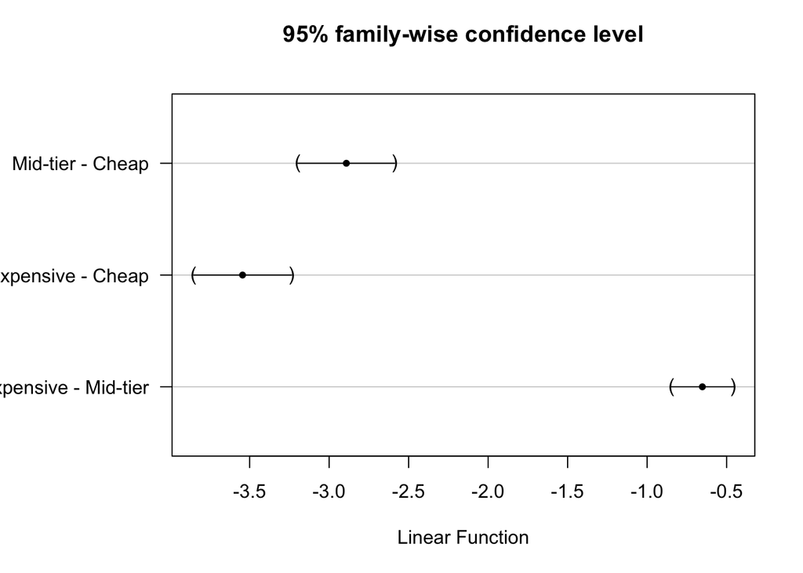

```r
par(mar = c(5.1,7.5,4.1,2.1))
plot(ph.test.THSD)
```

This plots shows us that the the difference between airline tiers is not zero in any case. Furthermore, the differences follow the possible intuition that cheaper flights are more likely to be delayed than mid-tier and expensive flights.

## 1.2 Interpretation of final model

### 1.2.1 Coefficients of Model

```r
print(summary(lm.arrival.4)$coefficients %>% round(digits = 7))
```

```
                            Estimate Std. Error    t value Pr(>|t|)
(Intercept)              -26.8580317  0.1316097 -204.07342        0
DEP_DELAY                  0.9760097  0.0010710  911.28750        0
TAXI_OUT                   0.9345674  0.0025172  371.27758        0
OP_CARRIER_TierMid-tier   -2.8916776  0.1307739  -22.11204        0
OP_CARRIER_TierExpensive  -3.5443432  0.1321894  -26.81262        0
```

- `DEP_DEALY`: given all predictors in the model are kept constant, a 1 minute increase in `DEP_DELAY` leads to an increase in `ARR_DELAY` of 0.976 minutes on *average*.
- `TAXI_OUT`: given all predictors in the model are kept constant, a 1 minute increase in `TAXI_OUT` leads to an increase in `ARR_DELAY` of 0.935 minutes on *average*.
- `Intercept`: With `DEP_DELAY` and `TAXI_OUT` being 0, the average `ARR_DELAY` of `Cheap Airlines` is -26.858. Meaning that **on average** these flights arrival 27 min early. While a departure delay of zero is realistic and in range of our data, the taxi out time of zero is not realistic. With min of taxi out being 1. We could center `TAXI_OUT` so that zero represents the average taxi out time.
- `TierMid-tier`: **on average** Mid-tier airlines arrive 2.892 minutes earlier compared to cheap airlines.
- `TierExpensive`: **on average** Expensive airlines arrive 3.544 minutes earlier compared to cheap airlines.

### 1.2.2 Model diagnostics

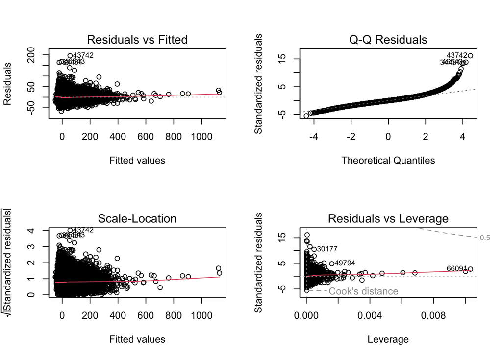

```r
par(mfrow = c(2, 2))
plot(lm.arrival.4)
```

- The `Q-Q plot` shows that the residuals are not normally distributed for higher values of `ARR_DELAY`.
- The `Fitted vs. Residuals plot` shows a clear case of heteroscedasticity where the variance is not constant across predicted values.

### 1.2.3 Transformation

Since we have a lot of negative and zero values, we can’t use log transformation. Therefore we try a cubic root transformation.

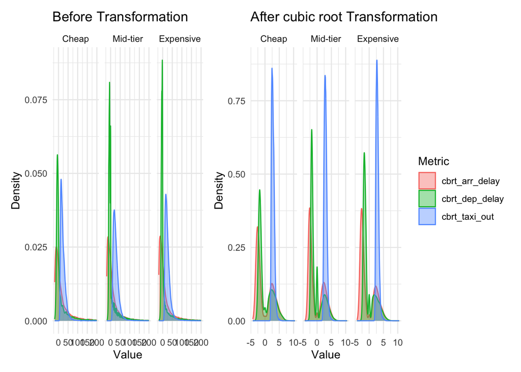

```r
planes %>%
  pivot_longer(cols = c(ARR_DELAY, TAXI_OUT, DEP_DELAY),
               names_to = "Metric",
               values_to = "Value") %>%
  ggplot(aes(x = Value, fill = Metric, color = Metric)) +
  geom_density(alpha = 0.4) +
  facet_wrap(~ OP_CARRIER_Tier) +
  xlim(-20, 200) +
  labs(
    title = "Before Transformation",
    x = "Value",
    y = "Density"
  ) +
  theme_minimal() +
  guides(fill = "none", color = "none") -> p1


cbrt_transform <- function(x) {
  sign(x) * abs(x)^(1/3)
}

planes %>%
  mutate(
    cbrt_arr_delay = cbrt_transform(ARR_DELAY),
    cbrt_dep_delay = cbrt_transform(DEP_DELAY),
    cbrt_taxi_out  = cbrt_transform(TAXI_OUT)
  ) %>%
  pivot_longer(cols = c(cbrt_arr_delay, cbrt_taxi_out, cbrt_dep_delay),
               names_to = "Metric",
               values_to = "Value") %>%
  ggplot(aes(x = Value, fill = Metric, color = Metric)) +
  geom_density(alpha = 0.4) +
  facet_wrap(~ OP_CARRIER_Tier) +
  labs(
    title = "After cubic root Transformation",
    x = "Value",
    y = "Density"
  ) +
  theme(legend.position = "top")+
  theme_minimal() -> p2

p1 + p2
```

The cubic root transformation produces a bimodal distribution for the `ARR_DELAY` and `DEP_DELAY` variables. Although this reveals an interesting pattern in the data, that most planes are on time (or more specific early) but the distribution shows slight delays to be somewhat common as well. Given the bimodality a normal regression modelling the average may not be better than using untransformed data. Interpretation of the model coefficents would become quit difficult after this transformation.

### 1.2.4 z-normalization

To help with interpretation and entangle the relative effects of `TAXI_OUT` and `DEP_DELAY` on `ARR_DELAY` we can z-normalize the variables. The model fit will not change (as shown later). But it will help with interpretation of the intercept since a z-value of zero represents the average of the variable.

```r
planes <- planes %>%
  mutate(
    z_dep_delay = scale(DEP_DELAY),
    z_taxi_out  = scale(TAXI_OUT)
  )

lm.arrival.5 <- lm(ARR_DELAY ~ z_dep_delay + z_taxi_out + OP_CARRIER_Tier, data = planes)
#plot(lm.arrival.5)
print(summary(lm.arrival.5)$coefficients %>% round(digits = 7))
```

```
                          Estimate Std. Error   t value Pr(>|t|)
(Intercept)               6.304374  0.1174445  53.67961        0
z_dep_delay              35.854511  0.0393449 911.28750        0
z_taxi_out               14.655536  0.0394733 371.27758        0
OP_CARRIER_TierMid-tier  -2.891678  0.1307739 -22.11204        0
OP_CARRIER_TierExpensive -3.544343  0.1321894 -26.81262        0
```

- `Intercept`: Cheap airlines with average depature delay and average taxi out arrive **on average** 6.30 minutes late.
- `TierMid-tier`: Mid-tier airlines with average depature delay and average taxi out arrive **on average** 3.413 minutes late.
- `TierExpensive`: Expensive airlines with average depature delay and average taxi out arrive **on average** 2.76 minutes late.
- This again shows that using the average for modelling may give us a biased picture.
- We see that `z_dep_delay` has a higher relative effect on arrival delay than `z_taxi_out`. This was not so clear in the model without transformation and is likely because depature delay has a larger range compared to taxi out time.

```r
vif(lm.arrival.5)
```

```
                    GVIF Df GVIF^(1/(2*Df))
z_dep_delay     1.006435  1        1.003212
z_taxi_out      1.012167  1        1.006065
OP_CARRIER_Tier 1.012168  2        1.003028
```

No collinearity problem

# 2 GAM

To increase flexibilty in our model we use GAM in our last created model

```r
gam.arrival.5 <- gam(ARR_DELAY ~ s(z_dep_delay) + s(z_taxi_out, by = OP_CARRIER_Tier) + OP_CARRIER_Tier, data = planes)
summary(gam.arrival.5)
```

```
Family: gaussian
Link function: identity

Formula:
ARR_DELAY ~ s(z_dep_delay) + s(z_taxi_out, by = OP_CARRIER_Tier) +
    OP_CARRIER_Tier

Parametric coefficients:
                         Estimate Std. Error t value            Pr(>|t|)
(Intercept)                6.1165     0.1206   50.72 <0.0000000000000002 ***
OP_CARRIER_TierMid-tier   -2.6551     0.1334  -19.90 <0.0000000000000002 ***
OP_CARRIER_TierExpensive  -3.4284     0.1350  -25.40 <0.0000000000000002 ***
---
Signif. codes:  0 '***' 0.001 '**' 0.01 '*' 0.05 '.' 0.1 ' ' 1

Approximate significance of smooth terms:
                                         edf Ref.df     F             p-value
s(z_dep_delay)                         7.625  8.402 99789 <0.0000000000000002
s(z_taxi_out):OP_CARRIER_TierCheap     4.502  5.217  2536 <0.0000000000000002
s(z_taxi_out):OP_CARRIER_TierMid-tier  5.105  6.007 11151 <0.0000000000000002
s(z_taxi_out):OP_CARRIER_TierExpensive 5.317  6.154  9839 <0.0000000000000002

s(z_dep_delay)                         ***
s(z_taxi_out):OP_CARRIER_TierCheap     ***
s(z_taxi_out):OP_CARRIER_TierMid-tier  ***
s(z_taxi_out):OP_CARRIER_TierExpensive ***
---
Signif. codes:  0 '***' 0.001 '**' 0.01 '*' 0.05 '.' 0.1 ' ' 1

R-sq.(adj) =  0.914   Deviance explained = 91.4%
GCV = 145.54  Scale est. = 145.5     n = 96069
```

We have high estimated degrees of freedom for our predictors indicating non-linearity in our relationship

# 3 GLM Poisson

Airports are hectic and resources can be limited if not managed properly. Coordination is key for good resource allocation. For example to clean the interior of a plane there is only a certain time window available. Since every minute counts we aim to predict the `Taxi in` time of a plane. In the case of plane cleaning, this knowledge would help with coordination and resource allocation.

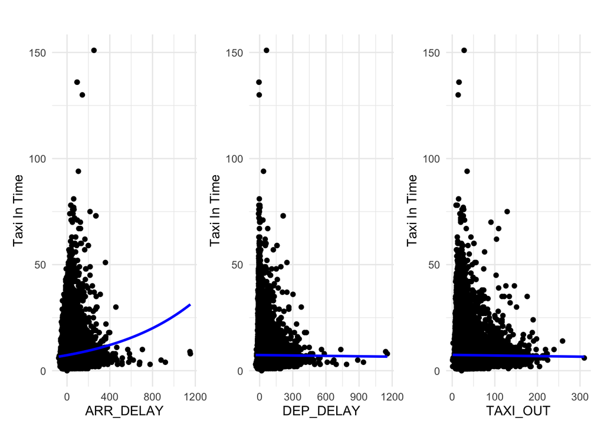

```r
p1<- planes %>%
  ggplot(aes(x = ARR_DELAY, y = TAXI_IN)) +
  geom_point() +
  geom_smooth(method = "glm",
              method.args = list(family = "quasipoisson"),
              formula = y ~ x,
              se = FALSE,
              color = "blue")+
  theme_minimal() +
  labs(title="",
       x = "ARR_DELAY",
       y = "Taxi In Time")

p2<- planes %>%
  ggplot(aes(x = DEP_DELAY, y = TAXI_IN)) +
  geom_point() +
  geom_smooth(method = "glm",
              method.args = list(family = "quasipoisson"),
              formula = y ~ x,
              se = FALSE,
              color = "blue")+
  theme_minimal() +
  labs(title="",
       x = "DEP_DELAY",
       y = "Taxi In Time")

p3 <- planes %>%
  ggplot(aes(x = TAXI_OUT, y = TAXI_IN)) +
  geom_point() +
  geom_smooth(method = "glm",
              method.args = list(family = "quasipoisson"),
              formula = y ~ x,
              se = FALSE,
              color = "blue")+
  theme_minimal() +
  labs(title="",
       x = "TAXI_OUT",
       y = "Taxi In Time")


p1 + p2 + p3 + plot_layout(ncol = 3)
```

We see that `ARR_DELAY` seems to have an influence on `TAXI_IN` time. The more delayed a plane arrives the longer it takes to taxi in.

```r
glm.poisson <- glm(TAXI_IN ~ ARR_DELAY*OP_CARRIER_Tier,
  family = "quasipoisson",
  data = planes)

print(summary(glm.poisson)$coefficients %>% round(digits = 7))
```

```
                                     Estimate Std. Error    t value  Pr(>|t|)
(Intercept)                         1.9777051  0.0063070 313.572945 0.0000000
ARR_DELAY                           0.0006679  0.0001187   5.627072 0.0000000
OP_CARRIER_TierMid-tier            -0.1370338  0.0070907 -19.325908 0.0000000
OP_CARRIER_TierExpensive            0.1691667  0.0069746  24.254637 0.0000000
ARR_DELAY:OP_CARRIER_TierMid-tier   0.0004641  0.0001388   3.342644 0.0008302
ARR_DELAY:OP_CARRIER_TierExpensive  0.0009579  0.0001345   7.121269 0.0000000
```

# 4 GLM Binomial

https://www.bazl.admin.ch/bazl/en/home/passagiere/air-passenger-rights/nichtbefoerderung–annullierung-und-grosse-verspaetungen/grosse-verspaetungen.html states a European court of justice ruling that passengers are entitled to compensation if their flight is delayed by more than 3 hours. *Due to the lack of a legal basis, the FOCA is unable to fine an airline for failure to pay compensation in the event of a delay*

**Aim: What airline has the most flights with more than 180 minutes delay and how are differences in proportions explained**

## 4.1 Percentage of flights with more than 180 minutes delay

```r
planes %>%
  mutate(index_late_dep = ifelse(DEP_DELAY > 180, 1, 0)) %>%
  group_by(OP_CARRIER) %>%
  summarise(
    Total_flights = n(),
    Total_delayed_dep = sum(index_late_dep == 1, na.rm = TRUE),
    percentage_delayed_dep = Total_delayed_dep / Total_flights * 100,
    Mean_dep_delay = mean(DEP_DELAY, na.rm = TRUE),
    Airline_tier = unique(OP_CARRIER_Tier)
  ) %>%
  arrange(desc(percentage_delayed_dep)) %>%
  head()
```

```
# A tibble: 6 × 6
  OP_CARRIER Total_flights Total_delayed_dep percentage_delayed_dep
  <fct>              <int>             <int>                  <dbl>
1 OO                    27                 1                   3.70
2 WN                  1422                40                   2.81
3 FL                  5954               107                   1.80
4 XE                   890                14                   1.57
5 CO                  3666                53                   1.45
6 YV                  1041                15                   1.44
# ℹ 2 more variables: Mean_dep_delay <dbl>, Airline_tier <fct>
```

We see very low percentages of flights that depart later than 180 minutes.

We will use aggregated data on a airline level. We will end up with 17 data points which should be kept in mind during interpretation. Furthermore, since the percentage of flights arrived 3 hours later is very low and similar. Therefore we will decrease the threshold to 30 minutes which increases the differences between airlines.

### 4.1.1 Aggregated Data

```r
planes_agg <- planes %>%
  mutate(index_late_dep = ifelse(DEP_DELAY > 30, 1, 0)) %>%
  group_by(OP_CARRIER) %>%
  summarise(
    OP_CARRIER = first(OP_CARRIER),
    Total_flights = n(),
    Total_delayed_dep_over30 = sum(index_late_dep == 1, na.rm = TRUE),
    Total_delayed_dep_under30 = sum(index_late_dep== 0, na.rm = TRUE),
    Mean_dep_delay = mean(DEP_DELAY, na.rm = TRUE),
    Mean_arr_delay = mean(ARR_DELAY, na.rm = TRUE),
    Mean_distance = mean(DISTANCE, na.rm = TRUE),
    Carrier_tier = unique(OP_CARRIER_Tier),
    .groups = "drop"
  )
```

```r
glm.late <- glm(cbind(Total_delayed_dep_over30, Total_delayed_dep_under30) ~
                 Carrier_tier + Mean_dep_delay + Mean_distance + Total_flights,
  family = "quasibinomial",
  data = na.omit(planes_agg))

print(summary(glm.late)$coefficients)
```

```
                             Estimate     Std. Error     t value
(Intercept)           -2.884661712402 0.185236007853 -15.5728994
Carrier_tierMid-tier   0.039102667464 0.107499989922   0.3637458
Carrier_tierExpensive -0.077424057928 0.125873286598  -0.6150952
Mean_dep_delay         0.075350839553 0.008433785936   8.9344027
Mean_distance          0.000194295108 0.000156893908   1.2383853
Total_flights          0.000004283091 0.000008836257   0.4847178
                               Pr(>|t|)
(Intercept)           0.000000007676316
Carrier_tierMid-tier  0.722942397711622
Carrier_tierExpensive 0.551004409194349
Mean_dep_delay        0.000002251561208
Mean_distance         0.241350687512443
Total_flights         0.637384586921758
```

```r
exp(coef(glm.late)["Mean_dep_delay"]*10) %>% round(digits=2)
```

```
Mean_dep_delay
          2.12
```

More specifically, the odds of airline flights being delayed by more than 30 minutes increase by 2.12 times for each 10 minutes increase in average departure delay and no evidence is found that airline tiers can explain differences in proportions of flights with more than 30 minutes delay. While interpretation one needs to keep in mind that we have few observation on the aggregated level and furthermore, both `Y` and `Mean_dep_delay` are calculated from the same data: `DEP_DELAY`.

# 5 Neural Network

Predicting departure delay

**Show Code of Model**

```r
# Include DEP_DELAY just for creating the target
important_features <- c("Month", "OP_CARRIER", "DEST", "CANCELLED",
                        "CANCELLATION_CODE", "CRS_DEP_TIME", "DISTANCE", "DEP_DELAY")

planes <- planes %>%
  filter(!is.na(DEP_TIME)) %>%
  mutate(delayed = as.factor(ifelse(DEP_DELAY > 0, "TRUE", "FALSE"))) %>%
  mutate(is_weekend = as.factor(ifelse(Weekday %in% c("Saturday", "Sunday"), 1, 0)))


LGA_cleaned <- planes[important_features]

# OR: Impute CANCELLED and CANCELLATION_CODE
#LGA_cleaned$CANCELLATION_CODE[is.na(LGA_cleaned$CANCELLATION_CODE)] <- "None"


# 1. Add departure hour from CRS_DEP_TIME
planes$dep_hour <- as.numeric(substr(sprintf("%04d", planes$CRS_DEP_TIME), 1, 2))

# 2. Bucket departure hours
planes$dep_hour_bucket <- cut(
  planes$dep_hour,
  breaks = c(-1, 5, 10, 15, 20, 24),
  labels = c("Late Night", "Morning", "Midday", "Afternoon", "Evening")
)

LGA_cleaned$FL_DATE <- as.Date(planes$FL_DATE[!is.na(planes$DEP_DELAY)])



# 5. Bucket flight distance
planes$distance_bucket <- cut(
  planes$DISTANCE,
  breaks = c(-1, 250, 750, 1500, Inf),
  labels = c("Short", "Medium", "Long", "Very Long")
)


# 🧼 Optional cleanup: remove raw dep_hour, keep bucket
LGA_cleaned <- planes %>%
  dplyr::select(Month, OP_CARRIER, DEST, CANCELLED, CANCELLATION_CODE, dep_hour_bucket, distance_bucket, delayed, is_weekend)

# Make sure new categorical vars are factors
LGA_cleaned$dep_hour_bucket <- as.factor(LGA_cleaned$dep_hour_bucket)
LGA_cleaned$distance_bucket <- as.factor(LGA_cleaned$distance_bucket)
LGA_cleaned$Month <- as.factor(LGA_cleaned$Month)


# Remove high NA columns if necessary, or impute here if needed

set.seed(123)
trainIndex <- createDataPartition(LGA_cleaned$delayed, p = 0.8, list = FALSE)
trainData <- LGA_cleaned[trainIndex, ]
testData  <- LGA_cleaned[-trainIndex, ]

# 2. One-hot encode all predictors
dummies <- dummyVars(~ ., data = trainData %>% dplyr::select(-delayed))
train_x <- predict(dummies, newdata = trainData) %>% as.data.frame()
test_x <- predict(dummies, newdata = testData) %>% as.data.frame()
print(nrow(test_x))
print(nrow(testData))

# 3. Create y-labels
train_y <- as.numeric(trainData$delayed) - 1
test_y <- as.numeric(testData$delayed) - 1

# 4. Remove zero-variance columns
nzv <- nearZeroVar(train_x, saveMetrics = TRUE)
zero_var_cols <- rownames(nzv[nzv$zeroVar == TRUE, ])
train_x <- train_x[, !(names(train_x) %in% zero_var_cols)]
test_x <- test_x[, !(names(test_x) %in% zero_var_cols)]
# Align column structure of test_x to train_x
missing_cols <- setdiff(names(train_x), names(test_x))
for (col in missing_cols) {
  test_x[[col]] <- 0
}
# Also reorder the columns to match train_x
test_x <- test_x[, names(train_x)]

# 5. Normalize


# Combine and convert to numeric
train_combined <- cbind(train_x, delayed = as.numeric(trainData$delayed) - 1)
# SMOTE (on unscaled data)
smote_result <- SMOTE(X = train_combined[, -ncol(train_combined)],
                      target = train_combined$delayed,
                      K = 5)

train_x_bal <- as.data.frame(smote_result$data[, -ncol(smote_result$data)])
train_y_bal <- as.numeric(as.character(smote_result$data$class))

# ✅ Now normalize AFTER SMOTE
preProc <- preProcess(train_x_bal, method = c("center", "scale"))
train_x_bal <- predict(preProc, train_x_bal)
test_x <- predict(preProc, test_x)


#install_keras()
# Rebuild model with correct input shape
model <- keras_model_sequential() %>%
  layer_dense(units = 64, activation = "relu", input_shape = ncol(train_x_bal)) %>%
  layer_dropout(rate = 0.3) %>%
  layer_dense(units = 32, activation = "relu") %>%
  layer_dense(units = 1, activation = "sigmoid")

# Compile
model %>% compile(
  loss = "binary_crossentropy",
  optimizer = optimizer_adam(),
  metrics = c("accuracy")
)

# Add early stopping callback
early_stop <- callback_early_stopping(
  monitor = "val_loss",
  patience = 5,
  restore_best_weights = TRUE
)

# Since ROSE is used, set equal class weights


# Train model
history <- model %>% fit(
  x = as.matrix(train_x_bal),
  y = train_y_bal,
  epochs = 50,
  batch_size = 32,
  validation_split = 0.2,
  callbacks = list(early_stop)
)



# Predict probabilities
pred_probs <- as.vector(model %>% predict(as.matrix(test_x)))

# Get optimized threshold
roc_obj <- roc(testData$delayed, pred_probs)
best_thresh <- coords(roc_obj, "best", ret = "threshold")[[1]]


# Classify using that threshold
pred_classes <- ifelse(pred_probs > best_thresh, "TRUE", "FALSE")
```

```r
# Evaluate
confusionMatrix(
  factor(pred_classes, levels = c("FALSE", "TRUE")),
  factor(testData$delayed, levels = c("FALSE", "TRUE"))
)
```

```
Confusion Matrix and Statistics

          Reference
Prediction FALSE TRUE
     FALSE  5123 1107
     TRUE   8512 4545

               Accuracy : 0.5013
                 95% CI : (0.4942, 0.5084)
    No Information Rate : 0.707
    P-Value [Acc > NIR] : 1

                  Kappa : 0.13

 Mcnemar's Test P-Value : <0.0000000000000002

            Sensitivity : 0.3757
            Specificity : 0.8041
         Pos Pred Value : 0.8223
         Neg Pred Value : 0.3481
             Prevalence : 0.7070
         Detection Rate : 0.2656
   Detection Prevalence : 0.3230
      Balanced Accuracy : 0.5899

       'Positive' Class : FALSE
```

# 6 Support Vector Machine

## 6.1 EDA and Data Preprocessing

### 6.1.1 Selecting the Target Variable

The first step involves selecting the dependent variable for classification using the Support Vector Machine (SVM) model. From a customer-oriented perspective, a key concern is whether a flight will arrive on time or experience a delay. The dataset includes a column labeled ARR_DELAY, which records the total delay in minutes upon arrival. To proceed, it is essential to examine the distribution of arrival delays in the dataset.

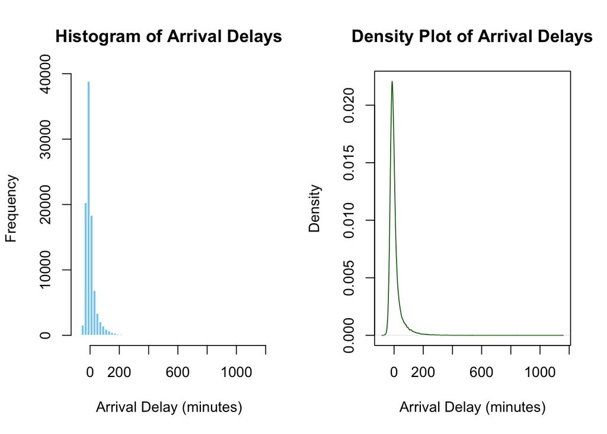

```r
planes_initial_svm <- planes
par(mfrow = c(1, 2))

hist(planes_initial_svm$ARR_DELAY,
     main = "Histogram of Arrival Delays",
     xlab = "Arrival Delay (minutes)",
     col = "skyblue",
     border = "white",
     breaks = 50)

plot(density(planes_initial_svm$ARR_DELAY, na.rm = TRUE),
     main = "Density Plot of Arrival Delays",
     xlab = "Arrival Delay (minutes)",
     col = "darkgreen")
```

The next step involves preprocessing the dataset by introducing a new binary target column. This column assigns a value of 1 to flights with an arrival delay greater than zero, indicating a delayed arrival, and a value of 0 to flights that arrived on time or early (arrival delay less than or equal to zero).

To evaluate the balance of the newly created target variable, we analyzeits class distribution. This allows us to assess the proportion of delayed versus non-delayed flights in the dataset.

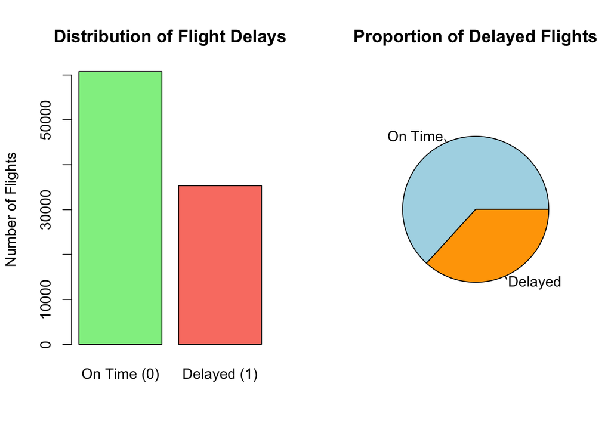

```r
# sum(is.na(planes_initial_svm$DELAYED))
# length(planes_initial_svm$DELAYED)


planes_initial_svm$DELAYED <- ifelse(planes_initial_svm$ARR_DELAY > 0, 1, 0)
par(mfrow = c(1, 2))

barplot(table(planes_initial_svm$DELAYED),
        names.arg = c("On Time (0)", "Delayed (1)"),
        col = c("lightgreen", "salmon"),
        main = "Distribution of Flight Delays",
        ylab = "Number of Flights")

pie(table(planes_initial_svm$DELAYED),
    labels = c("On Time", "Delayed"),
    col = c("lightblue", "orange"),
    main = "Proportion of Delayed Flights")
```

```r
# mean(planes_initial_svm$DELAYED, na.rm = TRUE)
```

The plot shows that 36.75% of the flights are classified as delayed. This indicates a reasonably balanced distribution between delayed and non-delayed flights, which is suitable for training a classification model like SVM.

### 6.1.2 Feature Selection & Engineering

Consistent with the approach used in the linear model, airlines are categorized into three pricing tiers: low-cost, mid-tier, and premium carriers.

```r
planes_initial_svm <- planes_initial_svm %>%
  dplyr::mutate(OP_CARRIER_Tier = dplyr::recode(OP_CARRIER,
    # Expensive
    "AA" = "Expensive",
    "DL" = "Expensive",
    "UA" = "Expensive",
    "CO" = "Expensive",

    # Cheap
    "B6" = "Cheap",
    "F9" = "Cheap",
    "FL" = "Cheap",
    "WN" = "Cheap",

    # Mid-tier
    "9E" = "Mid-tier",
    "EV" = "Mid-tier",
    "MQ" = "Mid-tier",
    "OH" = "Mid-tier",
    "OO" = "Mid-tier",
    "XE" = "Mid-tier",
    "YV" = "Mid-tier",
    "NW" = "Mid-tier",
    "US" = "Mid-tier",

    .default = NA_character_
  )) %>%
  dplyr::mutate(OP_CARRIER_Tier = factor(OP_CARRIER_Tier,
                                  levels = c("Cheap", "Mid-tier", "Expensive")))
```

A key requirement for the SVM classification task is to limit input features to those available prior to flight departure. This ensures that the model operates under realistic conditions where only pre-departure information is accessible. Accordingly, the initial set of features will be selected based on their availability before takeoff.:

| Variable | Class | Description |
| --- | --- | --- |
| FL_DATE | Date | Date of the flight (yy/mm/dd) |
| OP_CARRIER | character | Airline Identifier |
| OP_CARRIER_FL_NUM | integer | Flight Number |
| DEST | character | Destination Airport Code |
| CRS_DEP_TIME | Date | Planned Departure Time (HH:MM) |
| CRS_ARR_TIME | Date | Planned Arrival Time |
| CRS_ELAPSED_TIME | integer | Planned time amount needed for the flight trip |
| DISTANCE | integer | Distance between two airports |
| OP_CARRIER_Tier | character | Category of carrier (e.g., major, regional) |
| DELAYED | integer | Target: 1 if ARR_DELAY > 0, else 0 |

```r
#|echo: false
planes_svm <- planes_initial_svm[, c("FL_DATE",
                         "OP_CARRIER_FL_NUM",
                         "DEST",
                         "CRS_DEP_TIME",
                         "CRS_ARR_TIME",
                         "CRS_ELAPSED_TIME",
                         "DISTANCE",
                         "OP_CARRIER_Tier",
                         "DELAYED")]

planes_svm <- na.omit(planes_svm)
#sum(is.na(planes_svm))
```

The OP_CARRIER feature is excluded from the model, as its information is sufficiently represented by the OP_CARRIER_Tier variable. To prepare OP_CARRIER_Tier for use in the SVM classifier, one-hot encoding is applied. This converts the categorical tier levels into a numerical format appropriate for classification.

```r
planes_svm <- cbind(planes_svm, model.matrix(~ OP_CARRIER_Tier - 1, data = planes_svm))
```

To utilize the date-related columns effectively, an appropriate transformation strategy must be established. Initially, the FL_DATE field is categorized into two temporal dimensions: weekday versus weekend, and calendar quarters. The use of calendar quarters is chosen over seasonal labels, as seasonal patterns vary significantly across different regions of the United States.

```r
planes_svm$DayType <- ifelse(weekdays(planes_svm$FL_DATE) %in% c("Saturday", "Sunday"),
                             "Weekend", "Weekday")
planes_svm$Quarter <- quarters(planes_svm$FL_DATE)

planes_svm$DayType <- factor(planes_svm$DayType, levels = c("Weekday", "Weekend"))
planes_svm$Quarter <- factor(planes_svm$Quarter, levels = c("Q1", "Q2", "Q3", "Q4"))
daytype_dummies <- model.matrix(~ DayType - 1, data = planes_svm)
quarter_dummies <- model.matrix(~ Quarter - 1, data = planes_svm)
planes_svm <- cbind(planes_svm, daytype_dummies, quarter_dummies)
planes_svm$DayType <- NULL
planes_svm$Quarter <- NULL
```

For the scheduled departure time (CRS_DEP_TIME) and scheduled arrival time (CRS_ARR_TIME) we will use cyclical encoding (see https://scholarworks.calstate.edu/downloads/pv63g5147).

```r
to_minutes <- function(hhmm) {
  hours <- hhmm %/% 100
  minutes <- hhmm %% 100
  return(hours * 60 + minutes)
}

planes_svm$DEP_MIN <- to_minutes(planes_svm$CRS_DEP_TIME)
planes_svm$ARR_MIN <- to_minutes(planes_svm$CRS_ARR_TIME)
max_minutes <- 24 * 60  # total minutes in a day
planes_svm$DEP_SIN <- sin(2 * pi * planes_svm$DEP_MIN / max_minutes)
planes_svm$DEP_COS <- cos(2 * pi * planes_svm$DEP_MIN / max_minutes)
planes_svm$ARR_SIN <- sin(2 * pi * planes_svm$ARR_MIN / max_minutes)
planes_svm$ARR_COS <- cos(2 * pi * planes_svm$ARR_MIN / max_minutes)

planes_svm <- subset(planes_svm, select = -c(CRS_DEP_TIME, CRS_ARR_TIME, DEP_MIN, ARR_MIN))
```

It would be interesting to also utilize the destination codes. Lets analyze the distribution of the destionation codes.

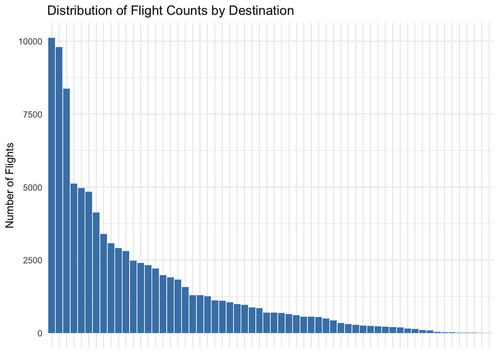

```r
# length(unique(planes_svm$DEST))
dest_counts <- as.data.frame(table(planes_svm$DEST))
ggplot(dest_counts, aes(x = reorder(Var1, -Freq), y = Freq)) +
  geom_bar(stat = "identity", fill = "steelblue") +
  labs(title = "Distribution of Flight Counts by Destination",
       x = NULL,
       y = "Number of Flights") +
  theme_minimal() +
  theme(axis.text.x = element_blank(),
        axis.ticks.x = element_blank())
```

The dataset includes 60 unique destination airports, exhibiting a long-tail distribution in terms of frequency. To manage this categorical feature effectively, destinations are first grouped based on traffic volume before applying one-hot encoding. Specifically, the eight most frequent destination airports are classified as “high-frequency,” while the remaining airports are grouped into an “other” category.

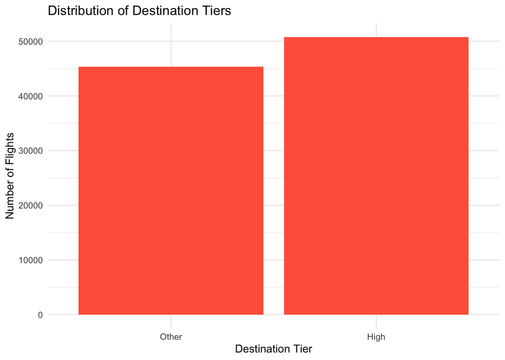

```r
dest_freq <- sort(table(planes_svm$DEST), decreasing = TRUE)
top_10_dest <- names(dest_freq)[1:8]
planes_svm$DEST_GROUPED <- ifelse(planes_svm$DEST %in% top_10_dest, "High", "Other")
planes_svm$DEST_GROUPED <- factor(planes_svm$DEST_GROUPED, levels = c("Other", "High"))


ggplot(planes_svm, aes(x = DEST_GROUPED)) +
  geom_bar(fill = "tomato") +
  labs(title = "Distribution of Destination Tiers",
       x = "Destination Tier",
       y = "Number of Flights") +
  theme_minimal()
```

Visual inspection of the resulting distribution reveals a relatively balanced split between the two groups, supporting the decision to proceed with this categorization. Let’s one-hot encode the destination group and remove redundant columns. Redundant columns, including the original destination identifier and the carrier flight number, are removed, as they do not contribute meaningful predictive value.

```r
dest_dummies <- model.matrix(~ DEST_GROUPED - 1, data = planes_svm)
planes_svm <- cbind(planes_svm, dest_dummies)
planes_svm$DEST_GROUPED <- NULL
planes_svm$DEST <- NULL
planes_svm$FL_DATE <- NULL
planes_svm$OP_CARRIER_FL_NUM <- NULL
planes_svm$OP_CARRIER_Tier <- NULL
```

At this stage, the final set of features is defined.

| Variable | Class | Description |
| --- | --- | --- |
| CRS_ELAPSED_TIME | integer | Planned time amount needed for the flight trip |
| DISTANCE | integer | Distance between two airports |
| DELAYED | integer | Target: 1 if ARR_DELAY > 0, else 0 |
| OP_CARRIER_Tier_* | numeric | One-hot encoded carrier category (e.g., major, regional, low-cost) |
| DayType_* | numeric | One-hot encoded day type (Weekday, Weekend) |
| Quarter_* | numeric | One-hot encoded calendar quarter (Q1–Q4) |
| DEP_SIN, DEP_COS | numeric | Cyclical encoding of scheduled departure time |
| ARR_SIN, ARR_COS | numeric | Cyclical encoding of scheduled arrival time |
| DEST_GROUPEDHigh | numeric | One-hot encoded indicator for high-traffic destinations |

Now the data is ready train and test a svm to predict DELAYED. All features are then normalized to ensure they are on a consistent scale. We will choose z-score scaling, but after splitting the data see https://forecastegy.com/posts/does-svm-need-feature-scaling-or-normalization/

## 6.2 SVM Modeling

```r
set.seed(123)
planes_svm <- planes_svm[sample(nrow(planes_svm)), ]

svm_train_index <- createDataPartition(planes_svm$DELAYED, p = 0.7, list = FALSE)
svm_train_data <- planes_svm[svm_train_index, ]
svm_test_data  <- planes_svm[-svm_train_index, ]

subset_index <- createDataPartition(svm_train_data$DELAYED, p = 0.3, list = FALSE)
svm_train_data <- svm_train_data[subset_index, ]

svm_train_data$DELAYED <- factor(svm_train_data$DELAYED, levels = c("0", "1"))
svm_test_data$DELAYED  <- factor(svm_test_data$DELAYED, levels = c("0", "1"))

preds <- setdiff(names(svm_train_data), "DELAYED")

train_scaled   <- scale(svm_train_data[preds])
scaling_params <- attributes(train_scaled)
#   scaling_params$`scaled:center`  = per-feature means
#   scaling_params$`scaled:scale`   = per-feature sds

svm_train_data[preds] <- train_scaled

svm_test_data[preds] <- scale(
  svm_test_data[preds],
  center = scaling_params$`scaled:center`,
  scale  = scaling_params$`scaled:scale`
)


train_control <- trainControl(method = "cv",
                              number = 5,
                              verboseIter = TRUE,
                              allowParallel = FALSE )
```

```r
# svm_model <- train(DELAYED ~ .,
#                   data = svm_train_data,
#                   method = "svmRadial",
#                   trControl = train_control,
#                   tuneLength = 3,
#                   preProcess = NULL
#                   )
#saveRDS(svm_model, file = "../Models/svm_model.rds")
# Load model
svm_model <- readRDS("../Models/svm_model.rds")
```

```r
predictions <- predict(svm_model, newdata = svm_test_data)
conf_matrix <- confusionMatrix(predictions, svm_test_data$DELAYED, positive = "1")
print(conf_matrix)
```

```
Confusion Matrix and Statistics

          Reference
Prediction     0     1
         0 16817  8416
         1  1635  1952

               Accuracy : 0.6512
                 95% CI : (0.6457, 0.6568)
    No Information Rate : 0.6402
    P-Value [Acc > NIR] : 0.00004952

                  Kappa : 0.1163

 Mcnemar's Test P-Value : < 0.00000000000000022

            Sensitivity : 0.18827
            Specificity : 0.91139
         Pos Pred Value : 0.54419
         Neg Pred Value : 0.66647
             Prevalence : 0.35975
         Detection Rate : 0.06773
   Detection Prevalence : 0.12446
      Balanced Accuracy : 0.54983

       'Positive' Class : 1
```

The Support Vector Machine (SVM) model achieved an accuracy of 65.12%, which is only marginally higher than the no-information rate of 64.02%. However, since the primary objective is to identify delayed flights, overall accuracy is less meaningful due to class imbalance. The model demonstrates high specificity (91.14%)—indicating strong performance in recognizing non-delayed flights—but its sensitivity is critically low at 18.8%, highlighting a substantial weakness in detecting the target class (delays). The balanced accuracy of 54.9% and a low kappa of 0.1163 further emphasize the model’s poor discriminatory power for delayed flights. To address this, the next step is to apply downsampling (via sampling = “down”) to reduce the dominance of the majority class and improve the model’s ability to correctly identify delayed flights.

```r
#set.seed(123)
#| echo: false

train_control <- trainControl(method = "cv",
                              number = 5,
                              sampling = "down",
                              verboseIter = TRUE,
                              allowParallel = FALSE )
```

```r
predictions_b <- predict(svm_model_down, newdata = svm_test_data)
conf_matrix_b <- confusionMatrix(predictions_b, svm_test_data$DELAYED, positive = "1")
print(conf_matrix_b)
```

```
Confusion Matrix and Statistics

          Reference
Prediction     0     1
         0 10177  3729
         1  8275  6639

               Accuracy : 0.5835
                 95% CI : (0.5778, 0.5892)
    No Information Rate : 0.6402
    P-Value [Acc > NIR] : 1

                  Kappa : 0.1751

 Mcnemar's Test P-Value : <0.0000000000000002

            Sensitivity : 0.6403
            Specificity : 0.5515
         Pos Pred Value : 0.4452
         Neg Pred Value : 0.7318
             Prevalence : 0.3598
         Detection Rate : 0.2304
   Detection Prevalence : 0.5175
      Balanced Accuracy : 0.5959

       'Positive' Class : 1
```

After downsampling, the SVM model achieved an accuracy of 58.4%, below the baseline of 64.02%, but sensitivity improved to 64.03%, indicating better detection of delayed flights—the primary goal. Specificity dropped to 55.15%, reflecting more false positives. Despite lower accuracy, balanced accuracy rose to 59.59% and kappa improved to 0.18, showing a better balance between classes. This trade-off is acceptable given the focus on delays. The next step is to apply recursive feature elimination (RFE) and rerun the model.

```r
set.seed(123)

slice30_idx <- createDataPartition(svm_train_data$DELAYED, p = 0.3, list = FALSE)
slice30     <- svm_train_data[slice30_idx, ]
slice30$DELAYED <- factor(slice30$DELAYED, levels = c("0","1"))


slice90_idx <- createDataPartition(slice30$DELAYED, p = 0.9, list = FALSE)
slice90     <- slice30[slice90_idx, ]

x_rfe   <- model.matrix(DELAYED ~ . - 1, data = slice90)
y_rfe   <- slice90$DELAYED

rfe_ctrl <- rfeControl(
  functions     = rfFuncs,
  method        = "cv",
  number        = 4,
  repeats       = 2,
  verbose       = TRUE,
  allowParallel = FALSE
)

rfe_results <- rfe(
  x          = x_rfe,
  y          = y_rfe,
  sizes      = c(1,2,3,4,5, 6, 7, 8, 9, 10, 11),
  rfeControl = rfe_ctrl
)

selected_features <- predictors(rfe_results)
print(selected_features)

train_sel <- data.frame(
  svm_train_data[, selected_features, drop = FALSE],
  DELAYED = svm_train_data$DELAYED
)

test_sel <- data.frame(
  svm_test_data[, selected_features, drop = FALSE],
  DELAYED = svm_test_data$DELAYED
)

train_ctrl <- trainControl(
  method      = "cv",
  number      = 5,
  sampling    = "down",
  verboseIter = TRUE,
  allowParallel = FALSE
)

#saveRDS(test_sel, file = "../Models/test_sel.rds")
```

```r
#svm_model_feature <- train(
#  DELAYED    ~ .,
#  data       = train_sel,
#  method     = "svmRadial",
#  trControl  = train_ctrl,
#  tuneLength = 3,
#  preProcess = NULL
#)

#saveRDS(svm_model_feature, file = "../Models/svm_model_feature.rds")

# Load model
svm_model_feature <- readRDS("../Models/svm_model_feature.rds")
test_sel<- readRDS("../Models/test_sel.rds")
```

```r
predicitons_c    <- predict(svm_model_feature, newdata = test_sel)
conf_matrix_c <- confusionMatrix(predicitons_c, test_sel$DELAYED, positive = "1")
print(conf_matrix_c)
```

```
Confusion Matrix and Statistics

          Reference
Prediction     0     1
         0  4824  1572
         1 13628  8796

               Accuracy : 0.4726
                 95% CI : (0.4668, 0.4784)
    No Information Rate : 0.6402
    P-Value [Acc > NIR] : 1

                  Kappa : 0.0875

 Mcnemar's Test P-Value : <0.0000000000000002

            Sensitivity : 0.8484
            Specificity : 0.2614
         Pos Pred Value : 0.3923
         Neg Pred Value : 0.7542
             Prevalence : 0.3598
         Detection Rate : 0.3052
   Detection Prevalence : 0.7781
      Balanced Accuracy : 0.5549

       'Positive' Class : 1
```

# 7 Conclusion

The dataset used in this task demonstrates limited predictive capability for determining whether a flight will experience a delayed departure or arrival. Two main strategies were explored for feature selection. One included all available features, while the other, more aligned with practical business considerations, limited the selection to features known before the aircraft begins to move. The latter approach was evaluated using a Support Vector Machine (SVM) model. However, even after applying feature engineering, the predictions produced by the SVM were not sufficiently accurate. Therefore, if an airport intends to provide travelers with advance notice of likely delays at their destination, incorporating additional features or experimenting with alternative models is necessary. For more reliable prediction we conclude that it would be vastly beneficial to collect additional features like weather or general airport traffic.

## 7.1 Usaged of AI

We used ChatGPT to assist with debugging code (such as data wrangling, plotting) and questions related to quarto, markdown. In one case we used ChatGPT to group the airlines into Tier level as outlined in Chapter 1.